# Assignment_9

Myles Ashbaker

## Introduction

#### This analysis explores how GRE scores, GPA, and the prestige (rank) of undergraduate institutions affect graduate school admissions. Admission is a binary outcome (1 = admitted, 0 = not admitted), so we apply logistic regression models to understand and predict it.

## Packages and Data

```r
library(tidyverse)
library(modelr)
library(easystats)
library(ggpubr)
library(caret)
library(GGally)
library(performance)
library(MASS)
```

##### Now, a quick glance at the structure and summary of the dataset gives a sense of the variables we’ll be working with.

```r
# Load the dataset
admissions <- read_csv("../../Data/GradSchool_Admissions.csv", show_col_types = FALSE) %>%
  mutate(
    admit = factor(admit),
    rank = factor(rank)
  )
```

```r
glimpse(admissions)
```

```
## Rows: 400
## Columns: 4
## $ admit <fct> 0, 1, 1, 1, 0, 1, 1, 0, 1, 0, 0, 0, 1, 0, 1, 0, 0, 0, 0, 1, 0, 1…
## $ gre   <dbl> 380, 660, 800, 640, 520, 760, 560, 400, 540, 700, 800, 440, 760,…
## $ gpa   <dbl> 3.61, 3.67, 4.00, 3.19, 2.93, 3.00, 2.98, 3.08, 3.39, 3.92, 4.00…
## $ rank  <fct> 3, 3, 1, 4, 4, 2, 1, 2, 3, 2, 4, 1, 1, 2, 1, 3, 4, 3, 2, 1, 3, 2…
```

```r
summary(admissions)
```

```
##  admit        gre             gpa        rank
##  0:273   Min.   :220.0   Min.   :2.260   1: 61
##  1:127   1st Qu.:520.0   1st Qu.:3.130   2:151
##          Median :580.0   Median :3.395   3:121
##          Mean   :587.7   Mean   :3.390   4: 67
##          3rd Qu.:660.0   3rd Qu.:3.670
##          Max.   :800.0   Max.   :4.000
```

##### We have 400 rows, and the outcome variable (`admit`) is binary. The predictors include continuous GRE scores, GPA values, and a categorical undergraduate institution `rank` from 1 (highest prestige) to 4 (lowest).

## Exploratory Analysis

##### To start, I’ll explore the pairwise relationships between the predictors and admission outcome. This can help reveal any obvious patterns or correlations that may guide model building.

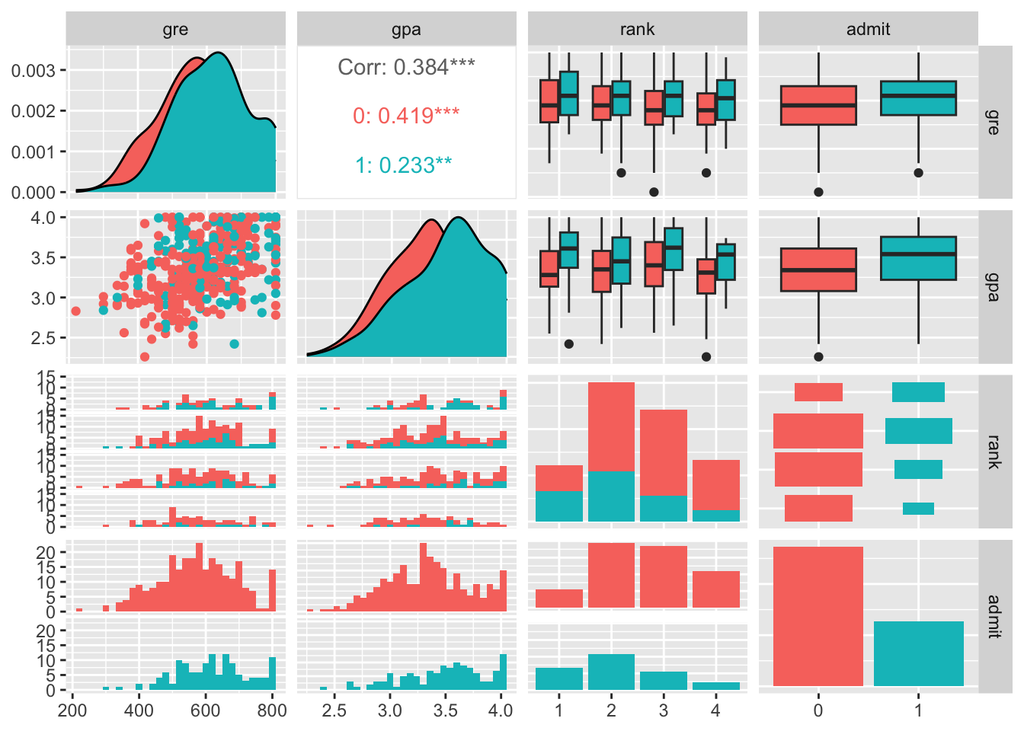

```r
admissions_subset <- dplyr::select(admissions, gre, gpa, rank, admit)
GGally::ggpairs(admissions_subset, aes(color = admit))
```

##### Let’s take a closer look at the distributions of GRE and GPA, broken down by admission outcome. This should give some insight into whether higher test scores or grades are associated with a greater chance of being admitted.

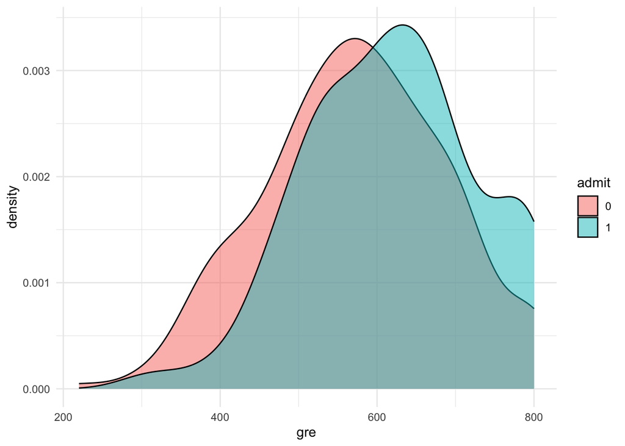

```r
admissions %>%
  ggplot(aes(x = gre, fill = admit)) +
  geom_density(alpha = 0.5) +
  theme_minimal()
```

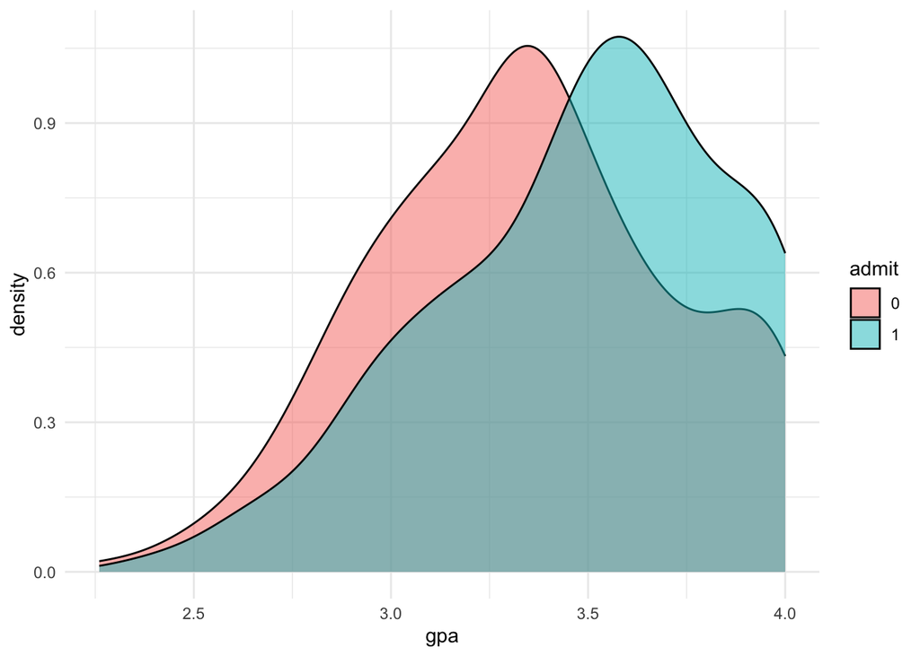

```r
admissions %>%
  ggplot(aes(x = gpa, fill = admit)) +
  geom_density(alpha = 0.5) +
  theme_minimal()
```

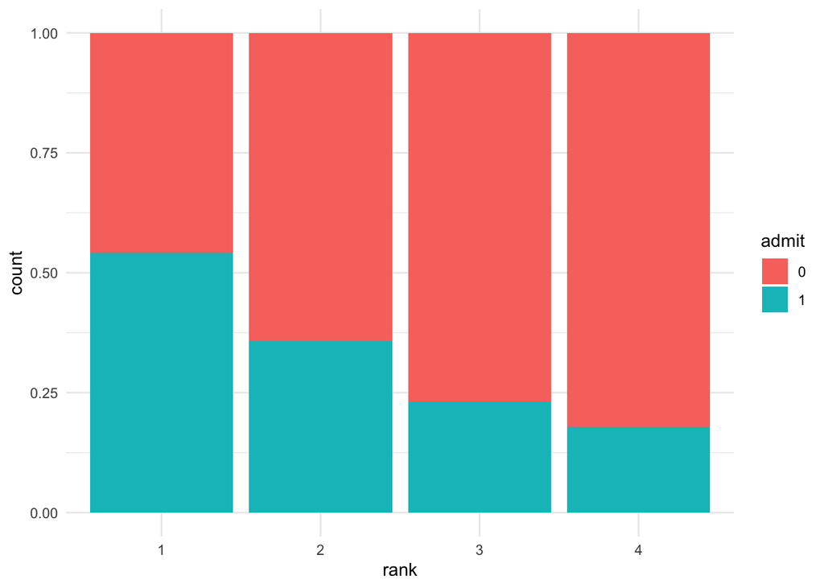

```r
admissions %>%
  ggplot(aes(x = rank, fill = admit)) +
  geom_bar(position = "fill") +
  theme_minimal()
```

## Modeling

##### Now, I’ll define a few logistic regression models with increasing complexity. Since the outcome is binary (admitted or not), logistic regression is appropriate. I’ll start simple and gradually add interaction terms and polynomial features to see how model fit improves.

```r
mod1 <- glm(admit ~ gre + gpa + rank, data = admissions, family = binomial)
mod2 <- glm(admit ~ gre * gpa + rank, data = admissions, family = binomial)
mod3 <- glm(admit ~ gre * gpa * rank, data = admissions, family = binomial)
mod4 <- glm(admit ~ gre * gpa * rank + I(gre^2) + I(gpa^2), data = admissions, family = binomial)
```

```r
full_mod <- glm(admit ~ gre * gpa * rank, data = admissions, family = binomial)
step <- stepAIC(full_mod, trace = 0)
mod5 <- glm(formula = step$formula, data = admissions, family = binomial)

# Simpler alternative
mod6 <- glm(admit ~ (gre + gpa) * rank, data = admissions, family = binomial)
```

## Model Comparison

##### With several models defined, I’ll compare their performance using metrics like AIC, R², and RMSE. This will help identify which model best balances complexity and fit.

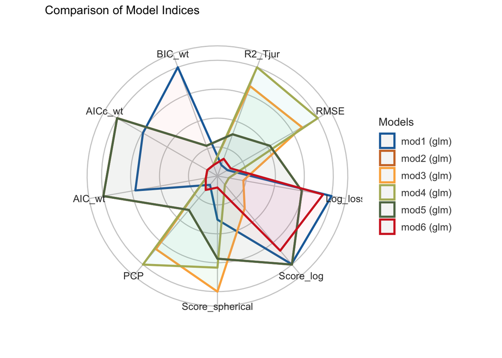

```r
compare_performance(mod1, mod2, mod3, mod4, mod5, mod6, rank = TRUE) %>% plot()
```

## Predictions vs Observations

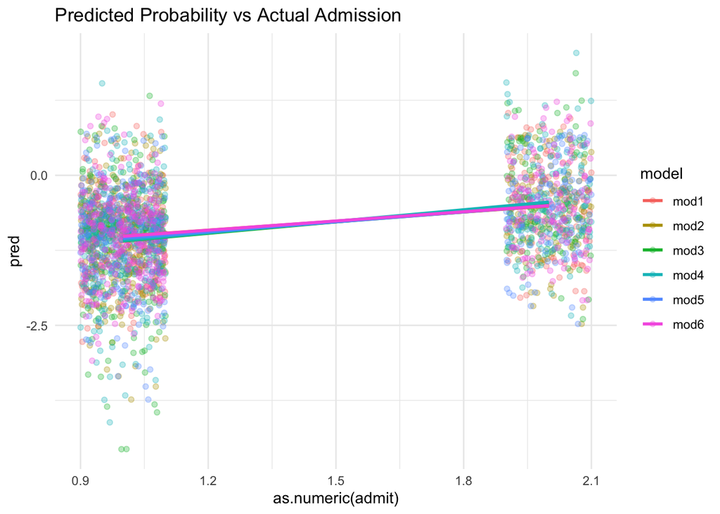

```r
admissions %>%
  gather_predictions(mod1, mod2, mod3, mod4, mod5, mod6) %>%
  ggplot(aes(x = as.numeric(admit), y = pred, color = model)) +
  geom_jitter(width = 0.1, alpha = 0.3) +
  geom_smooth(method = "lm", se = FALSE) +
  theme_minimal() +
  labs(title = "Predicted Probability vs Actual Admission")
```

## Cross-Validation

##### I’ll now split the data into training and testing sets (to guard against overfitting). By fitting models on one subset and evaluating them on another, we get a better sense of how they’ll generalize to new data.

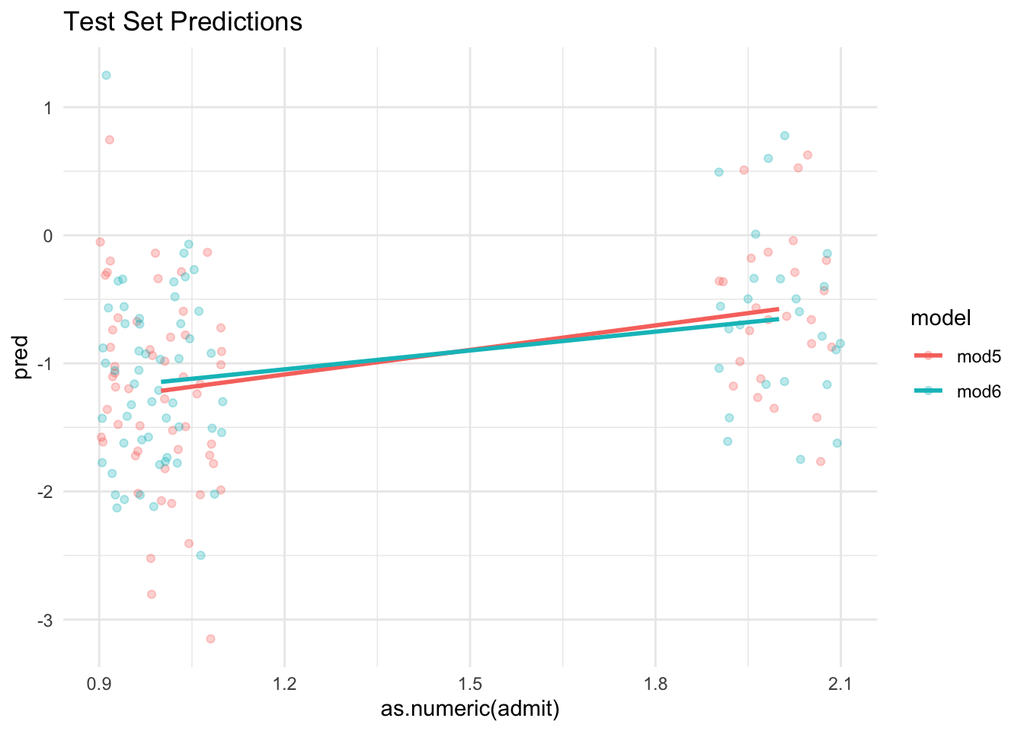

```r
set.seed(123)
train_index <- createDataPartition(admissions$admit, p = 0.8, list = FALSE)
train_data <- admissions[train_index, ]
test_data <- admissions[-train_index, ]

# Refit models
mod5 <- glm(formula = mod5$formula, data = train_data, family = binomial)
mod6 <- glm(formula = mod6$formula, data = train_data, family = binomial)

# Predict on test set
gather_predictions(test_data, mod5, mod6) %>%
  ggplot(aes(x = as.numeric(admit), y = pred, color = model)) +
  geom_jitter(width = 0.1, alpha = 0.3) +
  geom_smooth(method = "lm", se = FALSE) +
  theme_minimal() +
  labs(title = "Test Set Predictions")
```

## Model Interpretation

##### Finally, I’ll interpret the coefficients from the final model to understand how each variable contributes to admission odds. This output includes log-odds estimates, but I’ll also consider converting to odds ratios for easier interpretation.

```r
model_parameters(mod6)
```

```
## Parameter      |  Log-Odds |       SE |          95% CI |         z |     p
## ---------------------------------------------------------------------------
## (Intercept)    |     -5.26 |     2.88 | [-11.34,  0.14] |     -1.83 | 0.068
## gre            |  2.82e-03 | 2.86e-03 | [ -0.00,  0.01] |      0.99 | 0.325
## gpa            |      1.07 |     0.84 | [ -0.54,  2.84] |      1.27 | 0.204
## rank [2]       |      1.16 |     3.50 | [ -5.59,  8.30] |      0.33 | 0.740
## rank [3]       |      1.02 |     3.64 | [ -6.07,  8.38] |      0.28 | 0.779
## rank [4]       |      1.62 |     4.93 | [ -8.21, 11.35] |      0.33 | 0.742
## gre × rank [2] | -2.21e-03 | 3.49e-03 | [ -0.01,  0.00] |     -0.63 | 0.527
## gre × rank [3] |  1.45e-03 | 3.79e-03 | [ -0.01,  0.01] |      0.38 | 0.703
## gre × rank [4] | -3.02e-05 | 4.51e-03 | [ -0.01,  0.01] | -6.70e-03 | 0.995
## gpa × rank [2] |     -0.16 |     1.00 | [ -2.20,  1.77] |     -0.16 | 0.870
## gpa × rank [3] |     -0.92 |     1.11 | [ -3.16,  1.25] |     -0.82 | 0.410
## gpa × rank [4] |     -0.92 |     1.47 | [ -3.85,  1.97] |     -0.62 | 0.532
```

```
##
## Uncertainty intervals (profile-likelihood) and p-values (two-tailed)
##   computed using a Wald z-distribution approximation.
```

```
##
## The model has a log- or logit-link. Consider using `exponentiate =
##   TRUE` to interpret coefficients as ratios.
```